# Anascombes_quartets_2

**Visualization versus summary statistics:- The lesson from Anscombe’s quartets**

Unless you have a done formal/ informal some course in statistics or data visualization, the chances are that you have never heard of Anscombe’s quartets.

This article is about three things:-

1. Visualization
2. Summary statistics
3. Anscombe’s quartets.

Lets begin with Anscombe’s quartets. According to [Wikipedia](https://en.wikipedia.org/wiki/Anscombe%27s_quartet)

*“Anscombe's quartet comprises four data sets that have nearly identical simple descriptive statistics, yet have very different distributions and appear very different when graphed. Each dataset consists of eleven (x,y) points.*

*They were constructed in 1973 by the statistician Francis Anscombe to demonstrate both the importance of graphing data before analyzing it and the effect of outliers and other influential observations on statistical properties”*

So to summarize, Anscombe’s quartets have:-

- Four data sets in form of x-y pairs. (Because the number of data pairs is 4, hence the term quartet).
- Each data set has 11 points.
- The "summary statistics" of all the four data sets are near equal or identical.
- But when these four data sets are plotted, they represent altogether different graphs.

We shall have a look at the data sets shortly, but lets understand the term "summary statistics". We won’t get into the semantics of the term. We just need to understand that when you compare two data sets "quantitatively", then you compare them on measures like:-

- Mean (Which is a measure of **central tendency**)
- Variance (Which is a measure of **spread**)
- Correlation (Which is a measure of **dependence**)
- Linear regression (Which indicates the **best fit line**)
- Coefficient of determination (which indicates **proportion of the variance in the dependent variable that is predictable from the independent variable**)

So without further delay, lets have a look at the Anscombe’s quartets.

We will do this exercise in following steps:-

**Step 1:- Download tables from the Wikipedia page on Anscombe’s quartets**

We will download the data from the [Wikipedia page](https://en.wikipedia.org/wiki/Anscombe%27s_quartet) using the `read_html()` function of a Panda’s `DataFrame`. This function can download tables from a html page directly. Note the word tables (plural form). So, if a page has more than one table, it will download it form of a "list of DataFrame objects". This wiki page (On Anscombe’s quartets) has in fact 2 tables. The first table gives the “summary statistics” of the quartet and the second table contains the 4 data sets.

The script to download the tables is as follows:-

```python
# Author:- Anurag Gupta  ## E-mail 999.anuraggupta@gmail.com
# The script can be downloaded from:-
import pandas as pd
# ----- STEP 1:- Read the data set from Wikipedia page
# You can see signature of pandas.read_html() at link in next line
# https://pandas.pydata.org/pandas-docs/version/0.23.4/generated/pandas.read_html.html
url = r'https://en.wikipedia.org/wiki/Anscombe%27s_quartet'
df = pd.read_html(url)
# This wikipedia page has 2 tables.
# First table (index 0) has summary stastics
# Second table (index 1) has the 4 data sets
print(df[0])  # prints summary statistics of the data set
df2 = df[1]  # df2 is simply an alias for df[1]
print(df2)  # Prints the 4 data sets in from of a DataFrame
```

```
                                            Property              Value  \
0                                          Mean of x                  9
1                             Sample variance of x :                 11
2                                          Mean of y               7.50
3                             Sample variance of y :              4.125
4                        Correlation between x and y              0.816
5                             Linear regression line  y = 3.00 + 0.500x
6  Coefficient of determination of the linear reg...               0.67

                                  Accuracy
0                                    exact
1                                    exact
2                      to 2 decimal places
3                                   ±0.003
4                      to 3 decimal places
5  to 2 and 3 decimal places, respectively
6                      to 2 decimal places
       I    I.1    II  II.1   III  III.1    IV   IV.1
0      x      y     x     y     x      y     x      y
1   10.0   8.04  10.0  9.14  10.0   7.46   8.0   6.58
2    8.0   6.95   8.0  8.14   8.0   6.77   8.0   5.76
3   13.0   7.58  13.0  8.74  13.0  12.74   8.0   7.71
4    9.0   8.81   9.0  8.77   9.0   7.11   8.0   8.84
5   11.0   8.33  11.0  9.26  11.0   7.81   8.0   8.47
6   14.0   9.96  14.0  8.10  14.0   8.84   8.0   7.04
7    6.0   7.24   6.0  6.13   6.0   6.08   8.0   5.25
8    4.0   4.26   4.0  3.10   4.0   5.39  19.0  12.50
9   12.0  10.84  12.0  9.13  12.0   8.15   8.0   5.56
10   7.0   4.82   7.0  7.26   7.0   6.42   8.0   7.91
11   5.0   5.68   5.0  4.74   5.0   5.73   8.0   6.89
```

**Step 2:- Cleaning the data**

I want to point out an interesting thing about the data set downloaded from the Wikipedia page. The screen shot of the data set on Wikipedia is as follows:-

[figure not shown]

(Image taken from:- [here](https://en.wikipedia.org/wiki/Anscombe%27s_quartet))

Notice that in the above table, the column names are I, II, III and IV and there is one column name for 2 columns. But Pandas is smart enough to recognize this and has named the columns as I, I.1, II, II.1, III, III.1 and IV, IV.1. Note that in some older versions of Pandas, the column names might show up as NaN. But that should not create a problem.

The cleaning of the data consists of following 3 steps:-

1. Rename the columns as `X1, Y1, X2, Y2, X3, Y3, X4 and Y4`
2. Remove the row (At index 0) containing x and y. Note that in some older versions of Pandas, the row containing x and y may appear at index 1. This might happen if the Pandas takes the column names as index 0. In that case, you simply need to remove the row at index 1.
3. Convert all items in the table into numerics.

The script part implementing step 2 is as follows:-

```python
# ----- STEP 2:- Clean the data
# Step 2(1) -- Change the column names
df2.columns = ['X1', 'Y1', 'X2', 'Y2', 'X3', 'Y3', 'X4', 'Y4']
# print(df2)  ## Uncomment to check that column names changed
# Step 2(2) -- Remove row containing x and y at index 0
df2.drop([0], axis = 0, inplace = True)
# print(df2)  ## Uncomment to confirm that row with x and y removed
# Step 2(3) -- convert all columns of DataFrame to numeric values
df2 = df2.apply(pd.to_numeric)
# print (df2.dtypes)  ## Uncomment to confirm that all cells of DataFrame have numerics
```

**Step 3:- Plotting the four data sets**

For plotting the 4 data sets, we will use the Matplotlib library.

As you may be aware, the pyplot module of the matplotlib library has a function subplots(). The signature of this function is given [here](https://matplotlib.org/3.2.1/api/_as_gen/matplotlib.pyplot.subplots.html).

The signature is as follows:-

`matplotlib.pyplot.subplots(nrows=1, ncols=1, sharex=False, sharey=False, squeeze=True, subplot_kw=None, gridspec_kw=None, **fig_kw)`

You can see the complete signature of the function along with description of all the parameters [here](https://matplotlib.org/3.2.1/api/_as_gen/matplotlib.pyplot.subplots.html)

The 2 important parameters are `nrows` and `ncols`. Since we need 4 sub-plots in a 2 x 2 grid, so we will give `nrows = 2` and `ncols = 2`. You can ignore the 2 additional arguments namely `sharex` and `sharey`. But for those who are interested, they can see the example code [here](https://matplotlib.org/3.1.0/gallery/subplots_axes_and_figures/subplots_demo.html)

The script part implementing step 3 is as follows:-

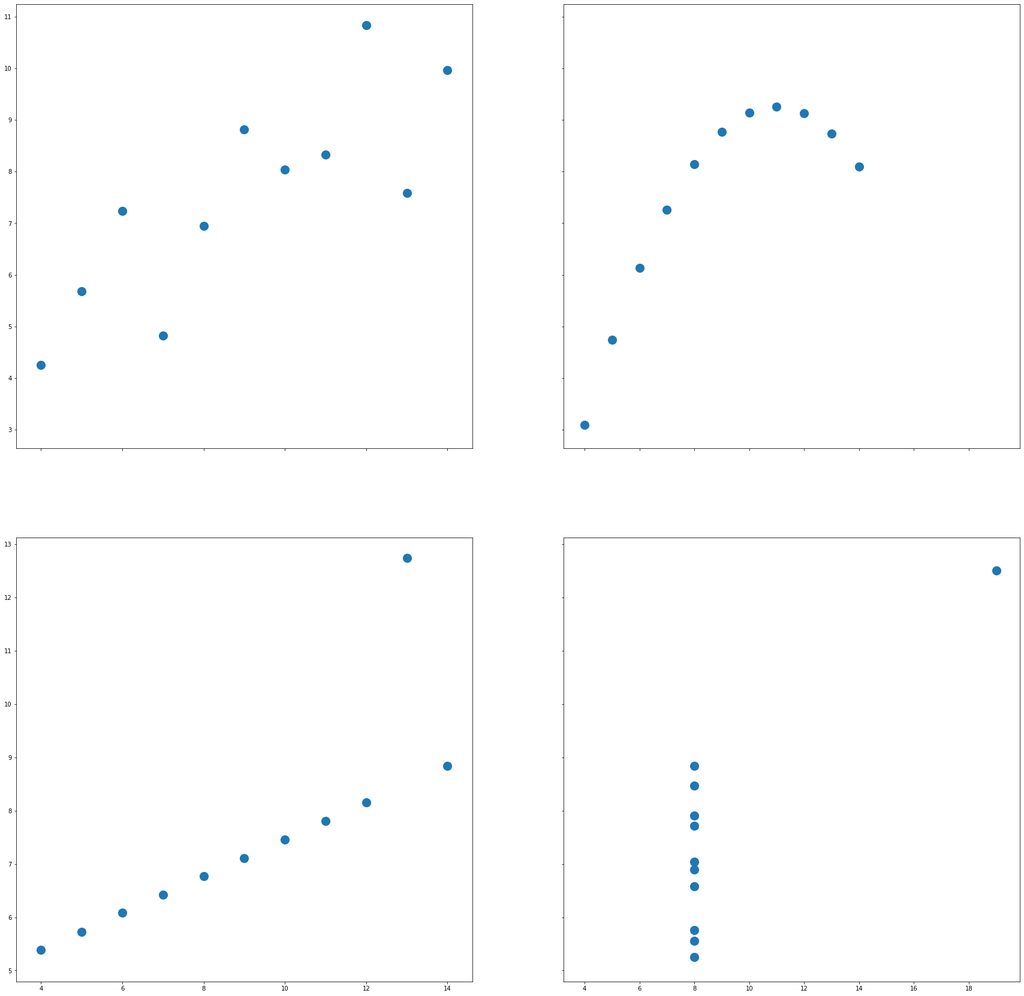

```python
# ----- STEP 3:- Plot the 4 data sets
%matplotlib inline
import matplotlib.pyplot as plt
# --- Step 3(1): Create 4 subplots
fig, ax = plt.subplots(nrows=2, ncols=2, figsize = (30, 30),
                       sharex = 'col', sharey = 'row')
# --- Step 3(2):- Create 4 Scatter Plots
ax[0][0].scatter(df2.X1, df2.Y1, s = 200)
ax[0][1].scatter(df2.X2, df2.Y2, s = 200)
ax[1][0].scatter(df2.X3, df2.Y3, s = 200)
ax[1][1].scatter(df2.X4, df2.Y4, s = 200)
```

**Step 4:- Plotting the linear regression line for the four sub-plots**

In this step we will plot the linear regression line or the “best fit” line for the four subplots. If you look back at the summary Statistics for the 4 data sets, you will notice that the Linear regression line was:- `y = 3.00 + 0.500x`

So from the high school maths equation for a straight line (`y = mx + c`), we know that for all these 4 data sets, the slope, that is `m = 0.500` and the y-intercept, that is `b = 3.00`.

Let us actually calculate the slope and the intercepts for each of these 4 "best fit" lines for each of the four data sets and see for ourselves that they match the given summary statistics.

For calculating the "best fit" lines, we will use a numpy function called `polyfit()`.

The signature as follows:-

`numpy.polyfit(x, y, deg, rcond=None, full=False, w=None, cov=False)`

The complete signature of numpy.polyfit() method is available [here](https://numpy.org/doc/stable/reference/generated/numpy.polyfit.html)

You need to understand that `polyfit()` has an attribute deg which takes the “degree” of the resulting polynomial to be created. For a linear function, we will take deg = 1.

The script part implementing step 4 is as follows:-

```
First dataset-> 0.5 3.0
Second dataset-> 0.5 3.0
Third dataset-> 0.5 3.0
Fourth dataset-> 0.5 3.0
[ 0  1  2  3  4  5  6  7  8  9 10 11 12 13 14 15]
```

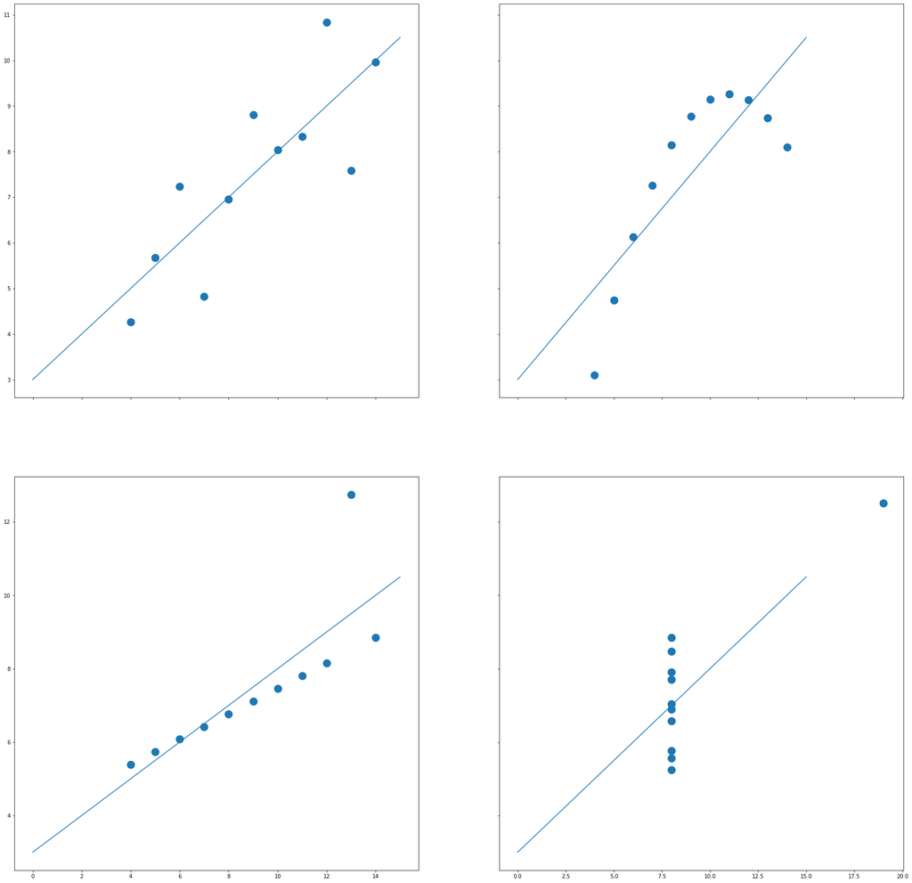

```python
# ----- STEP 4:- Plot the linear regression lines for the 4 plots
# Use numpy.polyfir() method. Signature is at link on next line
# https://numpy.org/doc/stable/reference/generated/numpy.polyfit.html
import numpy as np
# Use polyfit() to get slope and intercept
m1, b1 = np.polyfit(df2.X1, df2.Y1, deg = 1)
print('First dataset->', round(m1, 2), round(b1, 2))
# m2 and b2 are same as m1 and b1
m2, b2 = np.polyfit(df2.X2, df2.Y2, deg = 1)
print('Second dataset->', round(m2, 2), round(b2, 2))
# m3 and b3 are same as m1 and b1
m3, b3 = np.polyfit(df2.X3, df2.Y3, deg = 1)
print('Third dataset->', round(m3, 2), round(b3, 2))
# m4 and b4 are same as m1 and b1
m4, b4 = np.polyfit(df2.X4, df2.Y4, deg = 1)
print('Fourth dataset->', round(m4, 2), round(b4, 2))
# Infact the slopes and intercepts of all 4 graphs is same.
# So we can add this best fit line to all 4 graphs as below:-
x = np.array(range(16))
print(x)
ax[0][0].plot(x, m1 * x + b1)
ax[0][1].plot(x, m2 * x + b2)
ax[1][0].plot(x, m3 * x + b3)
ax[1][1].plot(x, m4 * x + b4)
fig
```

**Conclusion**  
So what did we learn? We learnt that “summary statistics” may not always give the true picture about a data set. So, to fully understand your data, you should also visualize it and the Anscombe’s data is proof of the fact that diverse data sets may look “similar” statistically but may have completely different visual representation.

**End note**

Just as an additional exercise, let us further explore the `numpy.polyfit()` function. Note that in general, `numpy.polyfit()` returns the coefficients in *descending* order of degree, according to the generation equation:-

$P(x) = C_n X^n + C_{(n-1)} X^{(n-1)} + ----- + C_0$

If case you noticed, the second data set in the Anscombe’s quartet showed a definite non-linear trend. Let us try to use the `numpy.polyfit()` function with degree 2 to see if we can find a “curve” which better fits this data set than a simple straight line.

```python
# ----- STEP 5:- Plot the degree 2 polyfit for the second data set
z = np.polyfit(df2.X2, df2.Y2, deg = 2)
print(z)
ax[0][1].plot(x, z[0] * x**2 + z[1] * x + z[2])
fig
```

[output not shown]

```
[-0.12671329  2.78083916 -5.99573427]
```

The entire script can be downloaded from [here](https://github.com/ag999git/jupyter_notebooks/blob/master/anscombes_quartets). Given below is the entire script at one place:-

```python
# Author:- Anurag Gupta  ## E-mail 999.anuraggupta@gmail.com
# The script can be downloaded from:-
# https://github.com/ag999git/jupyter_notebooks/blob/master/anscombes_quartets
import pandas as pd
# ----- STEP 1:- Read the data set from Wikipedia page
# You can see signature of pandas.read_html() at link in next line
# https://pandas.pydata.org/pandas-docs/version/0.23.4/generated/pandas.read_html.html
url = r'https://en.wikipedia.org/wiki/Anscombe%27s_quartet'
df = pd.read_html(url)
# This wikipedia page has 2 tables.
# First table (index 0) has summary stastics
# Second table (index 1) has the 4 data sets
print(df[0])  # prints summary statistics of the data set
df2 = df[1]  # df2 is simply an alias for df[1]
print(df2)  # Prints the 4 data sets in from of a DataFrame

# ----- STEP 2:- Clean the data
# Step 2(1) -- Change the column names
df2.columns = ['X1', 'Y1', 'X2', 'Y2', 'X3', 'Y3', 'X4', 'Y4']
# print(df2)  ## Uncomment to check that column names changed
# Step 2(2) -- Remove row containing x and y at index 0
df2.drop([0], axis = 0, inplace = True)
# print(df2)  ## Uncomment to confirm that row with x and y removed
# Step 2(3) -- convert all columns of DataFrame to numeric values
df2 = df2.apply(pd.to_numeric)
# print (df2.dtypes)  ## Uncomment to confirm that all cells of DataFrame have numerics

# ----- STEP 3:- Plot the 4 data sets
%matplotlib inline
import matplotlib.pyplot as plt
# --- Step 3(1): Create 4 subplots
fig, ax = plt.subplots(nrows=2, ncols=2, figsize = (30, 30),
                       sharex = 'col', sharey = 'row')
# --- Step 3(2):- Create 4 Scatter Plots
ax[0][0].scatter(df2.X1, df2.Y1, s = 200)
ax[0][1].scatter(df2.X2, df2.Y2, s = 200)
ax[1][0].scatter(df2.X3, df2.Y3, s = 200)
ax[1][1].scatter(df2.X4, df2.Y4, s = 200)

# ----- STEP 4:- Plot the linear regression lines for the 4 plots
# Use numpy.polyfir() method. Signature is at link on next line
# https://numpy.org/doc/stable/reference/generated/numpy.polyfit.html
import numpy as np
# Use polyfit() to get slope and intercept
m1, b1 = np.polyfit(df2.X1, df2.Y1, deg = 1)
print('First dataset->', round(m1, 2), round(b1, 2))
# m2 and b2 are same as m1 and b1
m2, b2 = np.polyfit(df2.X2, df2.Y2, deg = 1)
print('Second dataset->', round(m2, 2), round(b2, 2))
# m3 and b3 are same as m1 and b1
m3, b3 = np.polyfit(df2.X3, df2.Y3, deg = 1)
print('Third dataset->', round(m3, 2), round(b3, 2))
# m4 and b4 are same as m1 and b1
m4, b4 = np.polyfit(df2.X4, df2.Y4, deg = 1)
print('Fourth dataset->', round(m4, 2), round(b4, 2))
# Infact the slopes and intercepts of all 4 graphs is same.
# So we can add this best fit line to all 4 graphs as below:-
x = np.array(range(16))
print(x)
ax[0][0].plot(x, m1 * x + b1)
ax[0][1].plot(x, m2 * x + b2)
ax[1][0].plot(x, m3 * x + b3)
ax[1][1].plot(x, m4 * x + b4)
fig

# ----- STEP 5:- Plot the degree 2 polyfit for the second data set
z = np.polyfit(df2.X2, df2.Y2, deg = 2)
print(z)
ax[0][1].plot(x, z[0] * x**2 + z[1] * x + z[2])
fig
```

```
                                            Property              Value  \
0                                          Mean of x                  9
1                             Sample variance of x :                 11
2                                          Mean of y               7.50
3                             Sample variance of y :              4.125
4                        Correlation between x and y              0.816
5                             Linear regression line  y = 3.00 + 0.500x
6  Coefficient of determination of the linear reg...               0.67

                                  Accuracy
0                                    exact
1                                    exact
2                      to 2 decimal places
3                                   ±0.003
4                      to 3 decimal places
```

[output cut: 21 more lines]